# Lab 14

11/19/2018

## Data Visdualization on Madarin Vowels

## Introduction

- Mandarin Chinese has a five-vowel system
1. [yi], [yu], [wu], [en] and [ai]
2. Four allophones for the **mid vovel**: [e], [o], [en] and [e]
3. Two allophones for the **low vovel**: [ai] and [ao]

## Research Gap

- What are the individual variances when producing these 9 vowels?
- Vowel space in Chinese?

## Current Study

This study investigates + native Chinese speakers' vowel distribution + non-native Chinese speakers' vowel distribution (L1 English)

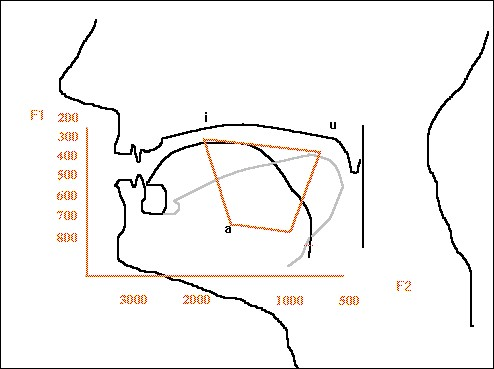

vocal tract

## Methods

### Participants

- 6 female native (L1) Mandarin speakers & 6 female non-native (L2) Mandarin speakers
- Average age
1. L1 Mandarin speakers was 26.3 (range: 23-30)
2. L2 Mandarin speakers was 22.3 (range: 18-28)
- Length of study: 6 months

## Methods

### Speech materials

- 9 Chinese sentences
- Each sentence includes one of the following nine vowels: [yi], [yu], [wu], [e], [o], [en], [e], [ai], [ao].
- Each vowel appears after the aspirated bilabial stop [p] with a high tone (55).

## Methods

### Procedure

- Sentence-repetition oral task
- Non-native speakers (NNS) and native Chinese speakers (NS) were asked to read the sentences twice.
- Formant 1 (F1) and Formant 2 (F2) were measured in the vowel mid-point for each vowel shown in the spectrogram through Praat.

## Data Organization

## Results

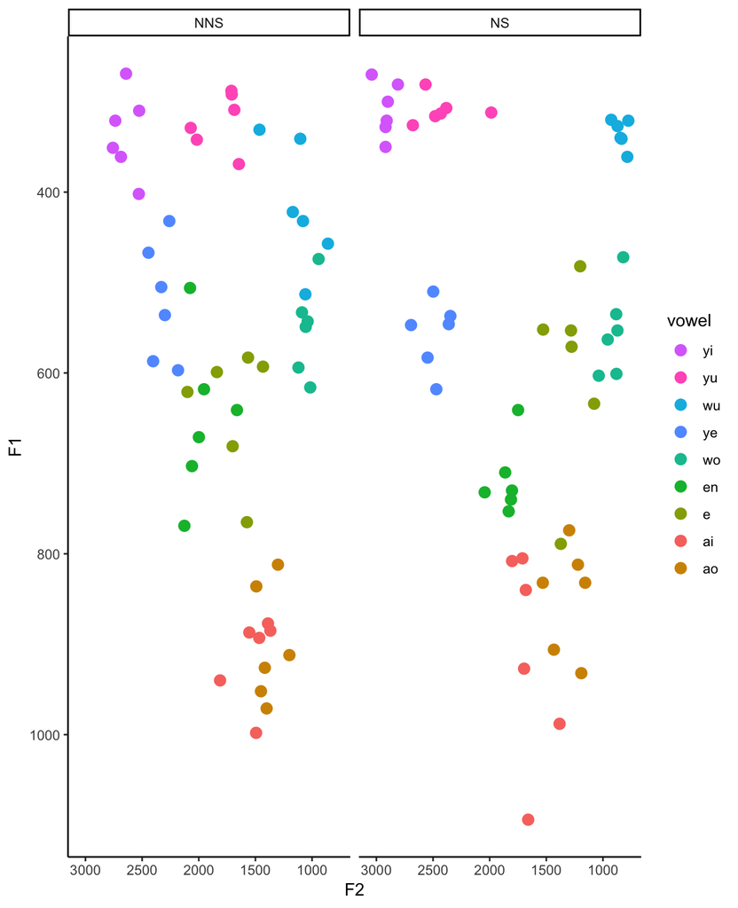

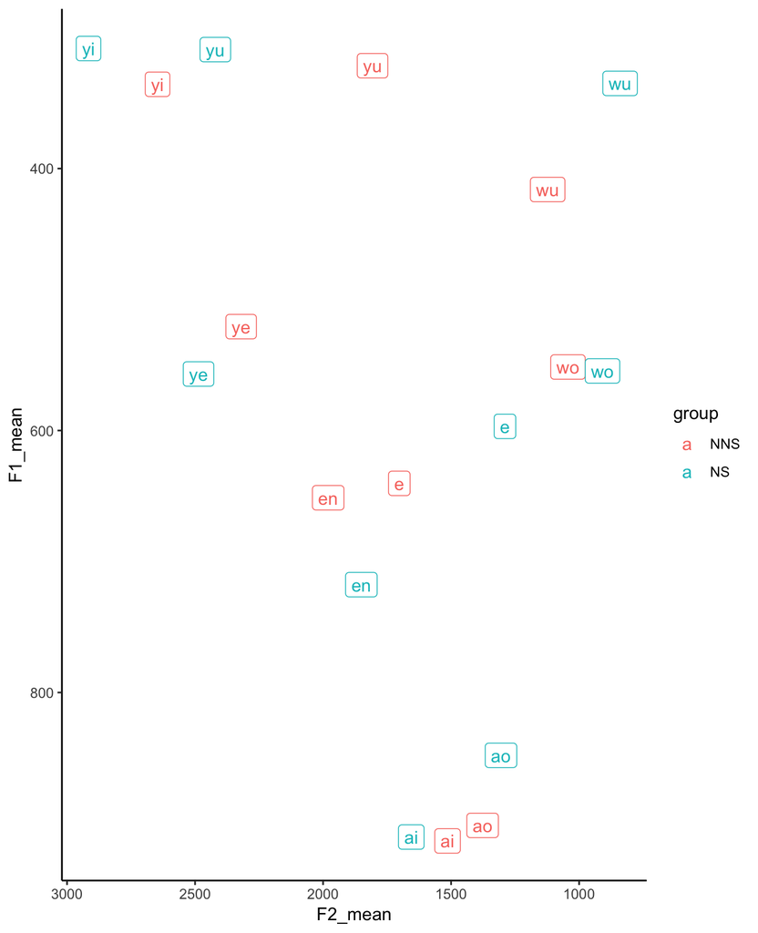

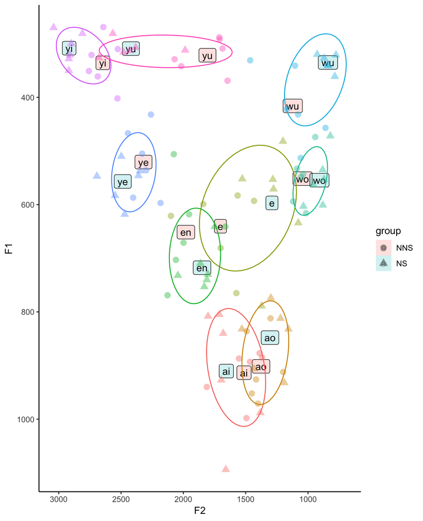